# Exploratory data anylysis

## 6 Тип кузова влияет на значение цены

```python
df.head()
```

|  | num | brand | model | year | price | region | median_salary | Region_en | NAME_1 | flg_more_average_salary | age | liters | horse_power | type_engine | transmission | machine_drive | mileage | flg_new_car | body_type |
| --- | --- | --- | --- | --- | --- | --- | --- | --- | --- | --- | --- | --- | --- | --- | --- | --- | --- | --- | --- |
| 0 | 1 | Mercedes-Benz | E-Class | 2006 | 830000 | Республика Адыгея | 38435.1 | Republic of Adygea | Adygey | 0 | 17 | 3.2 | 204.0 | дизель | автомат | задний | 350.0 | 0 | Седан |
| 1 | 1 | Mercedes-Benz | E-Class | 1999 | 280000 | Республика Адыгея | 38435.1 | Republic of Adygea | Adygey | 0 | 24 | 2.8 | 193.0 | бензин | автомат | задний | 360.0 | 0 | Седан |
| 2 | 1 | Mercedes-Benz | E-Class | 1991 | 200000 | Республика Адыгея | 38435.1 | Republic of Adygea | Adygey | 0 | 32 | 3.0 | 220.0 | бензин | автомат | задний | 352.0 | 0 | Седан |
| 3 | 1 | Mercedes-Benz | C-Class | 2011 | 900000 | Республика Адыгея | 38435.1 | Republic of Adygea | Adygey | 0 | 12 | 1.8 | 156.0 | бензин | автомат | задний | 134.0 | 0 | Седан |
| 4 | 1 | Mercedes-Benz | A-Class | 2000 | 250000 | Республика Адыгея | 38435.1 | Republic of Adygea | Adygey | 0 | 23 | 1.6 | 102.0 | бензин | механика | передний | 228.0 | 0 | Хэтчбэк |

```python
df.info()
```

```
<class 'pandas.core.frame.DataFrame'>
Int64Index: 26068 entries, 0 to 26813
Data columns (total 19 columns):
 #   Column                   Non-Null Count  Dtype
---  ------                   --------------  -----
 0   num                      26068 non-null  int64
 1   brand                    26068 non-null  object
 2   model                    26068 non-null  object
 3   year                     26068 non-null  int64
 4   price                    26068 non-null  int64
 5   region                   26068 non-null  object
 6   median_salary            26068 non-null  float64
 7   Region_en                26068 non-null  object
 8   NAME_1                   26068 non-null  object
 9   flg_more_average_salary  26068 non-null  int32
 10  age                      26068 non-null  int64
 11  liters                   26068 non-null  float64
 12  horse_power              26068 non-null  float64
 13  type_engine              26068 non-null  object
 14  transmission             26068 non-null  object
 15  machine_drive            26068 non-null  object
 16  mileage                  26068 non-null  float64
 17  flg_new_car              26068 non-null  int32
 18  body_type                26068 non-null  object
dtypes: float64(4), int32(2), int64(4), object(9)
memory usage: 3.8+ MB
```

```python
df.shape
```

```
(26068, 19)
```

```python
df[5:]
```

|  | num | brand | model | year | price | region | median_salary | Region_en | NAME_1 | flg_more_average_salary | age | liters | horse_power | type_engine | transmission | machine_drive | mileage | flg_new_car | body_type |
| --- | --- | --- | --- | --- | --- | --- | --- | --- | --- | --- | --- | --- | --- | --- | --- | --- | --- | --- | --- |
| 5 | 1 | Mercedes-Benz | GL-Class | 2008 | 1430000 | Республика Адыгея | 38435.1 | Republic of Adygea | Adygey | 0 | 15 | 3.0 | 224.0 | дизель | автомат | 4WD | 308.0 | 0 | Внедорожники |
| 6 | 1 | Mercedes-Benz | E-Class | 2003 | 685000 | Республика Адыгея | 38435.1 | Republic of Adygea | Adygey | 0 | 20 | 1.8 | 163.0 | бензин | автомат | задний | 346.0 | 0 | Седан |
| 7 | 1 | Mercedes-Benz | C-Class | 1993 | 180000 | Республика Адыгея | 38435.1 | Republic of Adygea | Adygey | 0 | 30 | 2.2 | 150.0 | бензин | автомат | задний | 301.0 | 0 | Седан |
| 8 | 1 | Mercedes-Benz | GLK-Class | 2013 | 1700000 | Республика Адыгея | 38435.1 | Republic of Adygea | Adygey | 0 | 10 | 2.1 | 170.0 | дизель | автомат | 4WD | 165.0 | 0 | Внедорожники |
| 9 | 1 | Mercedes-Benz | M-Class | 2009 | 1190000 | Республика Адыгея | 38435.1 | Republic of Adygea | Adygey | 0 | 14 | 3.0 | 224.0 | дизель | автомат | 4WD | 380.0 | 0 | Внедорожники |
| ... | ... | ... | ... | ... | ... | ... | ... | ... | ... | ... | ... | ... | ... | ... | ... | ... | ... | ... | ... |
| 26809 | 89 | Mercedes-Benz | M-Class | 2007 | 1000000 | Ямало-Ненецкий автономный округ | 130037.6 | Yamalo-Nenets Autonomous Okrug | Yamal-Nenets | 1 | 16 | 5.0 | 306.0 | бензин | автомат | 4WD | 299.0 | 0 | Внедорожники |
| 26810 | 89 | Mercedes-Benz | E-Class | 2005 | 550000 | Ямало-Ненецкий автономный округ | 130037.6 | Yamalo-Nenets Autonomous Okrug | Yamal-Nenets | 1 | 18 | 3.5 | 272.0 | бензин | автомат | задний | 350.0 | 0 | Седан |
| 26811 | 89 | Mercedes-Benz | M-Class | 1998 | 550000 | Ямало-Ненецкий автономный округ | 130037.6 | Yamalo-Nenets Autonomous Okrug | Yamal-Nenets | 1 | 25 | 3.2 | 218.0 | бензин | автомат | 4WD | 398.0 | 0 | Внедорожники |
| 26812 | 89 | Mercedes-Benz | E-Class | 1999 | 300000 | Ямало-Ненецкий автономный округ | 130037.6 | Yamalo-Nenets Autonomous Okrug | Yamal-Nenets | 1 | 24 | 2.4 | 170.0 | бензин | механика | задний | 309.0 | 0 | Седан |
| 26813 | 89 | Mercedes-Benz | CLS-Class | 2007 | 1600000 | Ямало-Ненецкий автономный округ | 130037.6 | Yamalo-Nenets Autonomous Okrug | Yamal-Nenets | 1 | 16 | 5.5 | 388.0 | бензин | автомат | задний | 164.0 | 0 | Купэ |

26063 rows × 19 columns

```python
df.isna().sum()
```

```
num                        0
brand                      0
model                      0
year                       0
price                      0
region                     0
median_salary              0
Region_en                  0
NAME_1                     0
flg_more_average_salary    0
age                        0
liters                     0
horse_power                0
type_engine                0
transmission               0
machine_drive              0
mileage                    0
flg_new_car                0
body_type                  0
dtype: int64
```

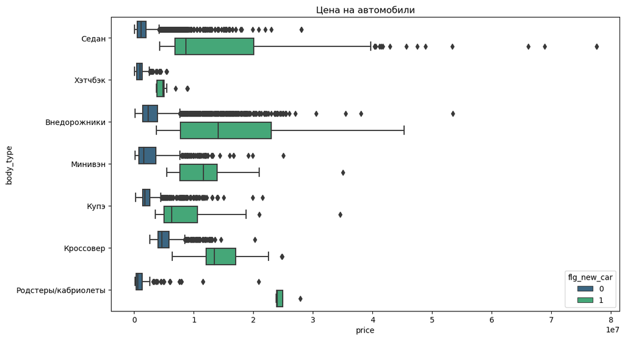

```python
plt.figure(figsize=(12, 7))

sns.boxplot(data=df,
            x='price',
            y='body_type',
            hue='flg_new_car',
            orient="h",
            palette='viridis')
plt.title('Цена на автомобили')
plt.show()
```

Большой достаточно разброс значений у седана, так как S-класс стоят дороже, чем некоторые внедорожники

Самые дешевые это кабриолеты/родстеры (связано с тем, большой средний возраст авто) и хэтчбеки, самые дорогие - кроссоверы

Можно отметить по соотношению кол-ва лет-цена, хэтчбэки по-сравнению с остальными типами наиболее дешевые

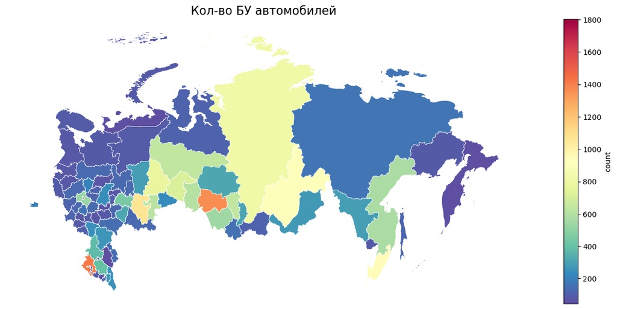

```python
plot_auto_geo(data=df[df.flg_new_car == 0],
              geo_data=russia_salary_geo,
              title='Кол-во БУ автомобилей',
              agg_col='price',
              func='count',
              group_col='NAME_1')
plt.show()
```

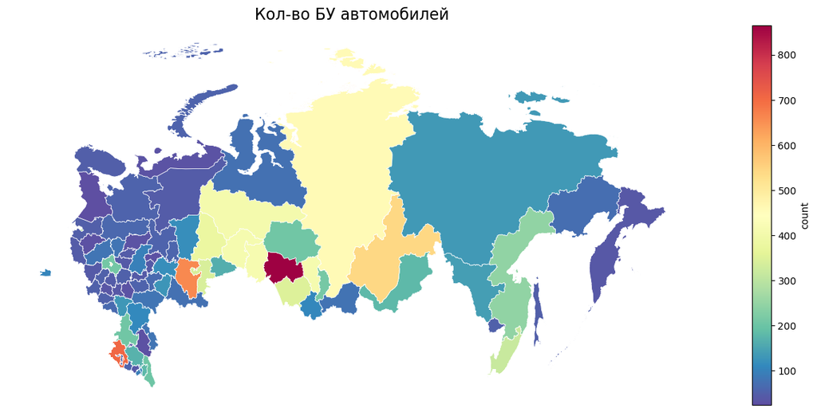

```python
plot_auto_geo(data=df[(df.age > 10) & (df.age < 30)],
              geo_data=russia_salary_geo,
              title='Кол-во БУ автомобилей',
              agg_col='price',
              func='count',
              group_col='NAME_1')
plt.show()
```

## 8 Цена на БУ авто ниже в регионах из выводов предыдущей гипотезы (предложение выше, цена ниже)

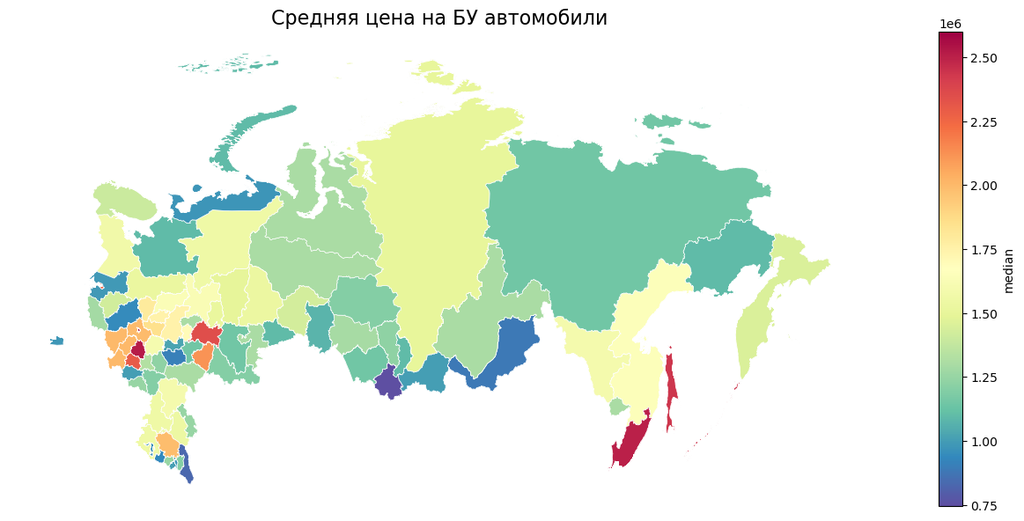

```python
plot_auto_geo(data=df[df.flg_new_car == 0],
              geo_data=russia_salary_geo,
              title='Средняя цена на БУ автомобили',
              agg_col='price',
              func='median',
              group_col='NAME_1')
plt.show()
```

нет. цена средняя.

Давайте посмотрим, насколько в % падают в цене автомобили по типу кузова

```python
df_pivot_diff = df[df.flg_new_car == 0].pivot_table(values='price',
                                                     index='body_type',
                                                     columns='age',
                                                     aggfunc='median')
```

```python
df_pivot_diff.head()
```

| age body_type | 1 | 2 | 3 | 4 | 5 | 6 | 7 | 8 | 9 | 10 | ... | 41 | 42 | 43 | 44 | 45 | 46 | 47 | 48 | 49 | 63 |
| --- | --- | --- | --- | --- | --- | --- | --- | --- | --- | --- | --- | --- | --- | --- | --- | --- | --- | --- | --- | --- | --- |
| Внедорожники | 11450000.0 | 6744999.5 | 5500000.0 | 5245000.0 | 3620000.0 | 3600000.0 | 3890000.0 | 2798000.0 | 2430000.0 | 2492500.0 | ... | 450000.0 | NaN | NaN | NaN | NaN | NaN | NaN | NaN | NaN | NaN |
| Кроссовер | 10869000.0 | 10800000.0 | 8200000.0 | 4502500.0 | 4700000.0 | 4200000.0 | 4325000.0 | 4195000.0 | NaN | NaN | ... | NaN | NaN | NaN | NaN | NaN | NaN | NaN | NaN | NaN | NaN |
| Купэ | 4200000.0 | 4670000.0 | 3400000.0 | 2849000.0 | 3100000.0 | 2124894.0 | 2190000.0 | 1750000.0 | 1673394.5 | 1550000.0 | ... | NaN | NaN | NaN | NaN | NaN | NaN | NaN | NaN | NaN | NaN |
| Минивэн | 6500000.0 | 10800000.0 | 6900000.0 | 5750000.0 | 4099000.0 | 3990000.0 | 3510000.0 | 2924999.5 | 2220000.0 | 1885000.0 | ... | NaN | NaN | NaN | NaN | NaN | NaN | NaN | NaN | NaN | NaN |
| Родстеры/кабриолеты | NaN | NaN | NaN | NaN | NaN | 5998000.0 | 4900000.0 | 3999999.5 | 2200000.0 | 2224500.0 | ... | NaN | NaN | NaN | NaN | NaN | 3590000.0 | NaN | NaN | NaN | 20900000.0 |

5 rows × 50 columns

```python
df_pivot_diff = df_pivot_diff.iloc[:, :5].dropna()
```

```python
df_pivot_diff['price_new_auto'] = df[df.flg_new_car == 1].groupby(
    'body_type')['price'].median()
```

```python
for i in range(1, 6):
    df_pivot_diff[f'diff_{i}_year'] = (
        df_pivot_diff['price_new_auto'] -
        df_pivot_diff[i]) / df_pivot_diff['price_new_auto']
```

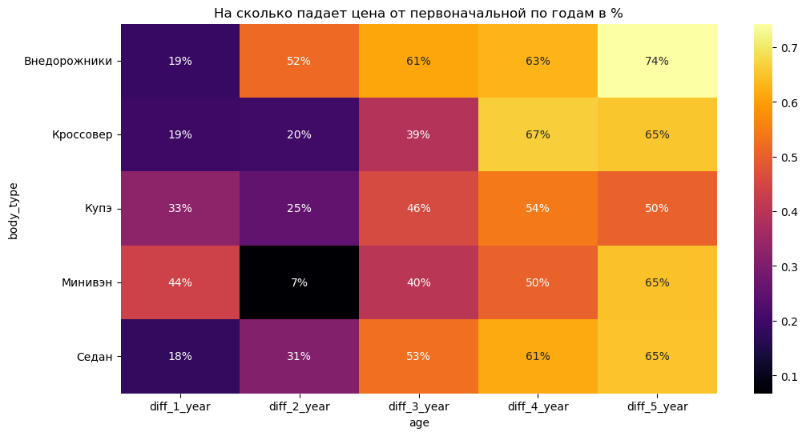

```python
plt.figure(figsize=(12, 6))

ax = sns.heatmap(df_pivot_diff.loc[:, 'diff_1_year':],
            cmap=colors[2],
            annot=True,
            fmt='.0%')
plt.title('На сколько падает цена от первоначальной по годам в %')
plt.show()
```

Начиная со 2го года эксплуатации в цене сильно падают внедорожники